# Kaggle - House Price Prediction

심정우

### 1. 도입

#### 1.1 케글 컴피션 정보

컴피션명 : 캐글 코리아와 함께하는 2nd ML 대회 - House Price Prediction  
컴피션 링크 : http://bitly.kr/5vlMjB

#### 1.2 컴피션 배경

내 집 마련의 꿈은 누구나 가지고 있습니다. 하지만 집의 가격은 누구나 알고 있지는 않습니다.  
집의 가격은 주거 공간의 면적, 위치, 경관, 건물의 연식 등 여러 가지 복잡한 요인의 조합에 의해 결정됩니다.  
이번에 분석하실 데이터는 20개의 변수를 가지고 있으며, 어떤 조건을 가진 집의 가격이 높고 낮은지를 예측하는 모델을 만드는 것을 목표로 합니다.

#### 1.3 컴피션 평가 방식

Root Mean Squared Error(RMSE)

#### 1.4 변수 정보

ID : 집을 구분하는 번호  
date : 집을 구매한 날짜  
price : 집의 가격  
bedrooms : 침실의 수  
bathrooms :  
- 1 : 화장실, 세면대, 샤워실, 욕조  
- 0.75 : 화장실, 세면대, 샤워실  
- 0.5 : 화장실, 세면대  
sqft_living : 주거 공간의 평방 피트(면적)  
sqft_lot : 부지의 평방 피트(면적)  
floors : 집의 층 수(0.5는 다락방)  
waterfront : 집의 전방에 강이 흐르는지 유무  
view : 집이 얼마나 좋아 보이는지의 정도  
condition : 집의 전반적인 상태  
grade : King County grading 시스템 기준으로 매긴 집의 등급  
sqft_above : 지하실을 제외한 평방 피트(면적)  
sqft_basement : 지하실의 평방 피트(면적)  
yr_built : 지어진 년도  
yr_renovated : 집을 재건축한 년도  
zipcode : 우편번호  
lat : 위도  
long : 경도  
sqft_living15 : 2015년 기준 주거 공간의 평방 피트(면적, 집을 재건축했다면, 변화가 있을 수 있음)  
sqft_lot15 : 2015년 기준 부지의 평방 피트(면적, 집을 재건축했다면, 변화가 있을 수 있음)

### 2. 라이브러리 로딩, 데이터 탐색, 함수 선언

#### 2.1 라이브러리 로딩

```r
library(dplyr)
library(ggplot2)
library(scales)
library(stringr)
library(corrplot)
library(data.table)
library(gridExtra)
library(caret)
library(xgboost)
library(randomForest)
library(Ckmeans.1d.dp)
```

#### 2.2 함수 선언

```r
rmse <- function(yi, yhat_i){
  sqrt(mean((yi - yhat_i)^2))
}
```

- RMSE 함수

```r
caretVariableImportanceImgView <- function(caretModel){
  caretVarimp <- varImp(fit_lasso,scale=F)

  caretImportance <- data.frame(
    variable=rownames(caretVarimp$importance),
    importance=caretVarimp$importance$Overall
  ) %>% arrange(importance)

  caretImportance$variable <- factor(
    caretImportance$variable,
    levels=caretImportance$variable,
    labels=caretImportance$variable
  )
  importanceGraph <- caretImportance %>%
    ggplot(aes(x=variable, y=importance, fill=variable)) +
    geom_bar(alpha=0.5, stat='identity') +
    coord_flip() +
    theme(legend.position="none")

  varsSelected <- length(which(caretImportance$importance!=0))
  varsNotSelected <- length(which(caretImportance$importance==0))
  selectCount <- paste('uses', varsSelected, 'variables in its model, and did not select', varsNotSelected, 'variables.')

  resultList <- list(
    graph=importanceGraph,
    catCount=selectCount
  )

  return(resultList)
}
```

- caret 중요 변수 출력 함수

#### 2.3 데이터 탐색

```r
test <- tbl_df(read.csv("./test.csv",stringsAsFactors=F))
train <- tbl_df(read.csv("./train.csv",stringsAsFactors=F))
```

- test, train 데이터를 불러옵니다.

```r
glimpse(test) #Observations : 6468 , Variables : 20
glimpse(train) #Observations : 15035 , Variables : 21
names(test)
names(train)
```

- test, train 데이터 구조를 확인합니다.

```r
test_id <- test$id
test$id <- NULL
train$id <- NULL
test$price <- NA
all <- rbind(train, test)

glimpse(all)
```

```
## Observations: 21,503
## Variables: 20
## $ date          <chr> "20141013T000000", "20150225T000000", "20150218T00…
## $ price         <dbl> 221900, 180000, 510000, 257500, 291850, 662500, 46…
## $ bedrooms      <int> 3, 2, 3, 3, 3, 3, 2, 3, 3, 5, 4, 3, 4, 2, 3, 4, 3,…
## $ bathrooms     <dbl> 1.00, 1.00, 2.00, 2.25, 1.50, 2.50, 1.00, 1.00, 1.…
## $ sqft_living   <int> 1180, 770, 1680, 1715, 1060, 3560, 1160, 1430, 137…
## $ sqft_lot      <int> 5650, 10000, 8080, 6819, 9711, 9796, 6000, 19901, …
## $ floors        <dbl> 1.0, 1.0, 1.0, 2.0, 1.0, 1.0, 1.0, 1.5, 1.0, 1.5, …
## $ waterfront    <int> 0, 0, 0, 0, 0, 0, 0, 0, 0, 0, 0, 0, 0, 0, 0, 0, 0,…
## $ view          <int> 0, 0, 0, 0, 0, 0, 0, 0, 0, 0, 3, 0, 0, 0, 0, 0, 4,…
## $ condition     <int> 3, 3, 3, 3, 3, 3, 4, 4, 4, 3, 3, 3, 4, 4, 4, 4, 3,…
## $ grade         <int> 7, 6, 8, 7, 7, 8, 7, 7, 7, 7, 9, 7, 7, 7, 7, 7, 9,…
## $ sqft_above    <int> 1180, 770, 1680, 1715, 1060, 1860, 860, 1430, 1370…
## $ sqft_basement <int> 0, 0, 0, 0, 0, 1700, 300, 0, 0, 0, 970, 0, 0, 0, 0…
## $ yr_built      <int> 1955, 1933, 1987, 1995, 1963, 1965, 1942, 1927, 19…
## $ yr_renovated  <int> 0, 0, 0, 0, 0, 0, 0, 0, 0, 0, 0, 0, 0, 0, 0, 0, 0,…
## $ zipcode       <int> 98178, 98028, 98074, 98003, 98198, 98007, 98115, 9…
## $ lat           <dbl> 47.5112, 47.7379, 47.6168, 47.3097, 47.4095, 47.60…
## $ long          <dbl> -122.257, -122.233, -122.045, -122.327, -122.315, …
## $ sqft_living15 <int> 1340, 2720, 1800, 2238, 1650, 2210, 1330, 1780, 13…
## $ sqft_lot15    <int> 5650, 8062, 7503, 6819, 9711, 8925, 6000, 12697, 1…
```

- 전처리를 반복하지 않도록 test, train을 하나의 데이터프레임으로 합칩니다.

### 3. 탐색적 자료 분석(EDA), Feature Engineering

#### 3.1 target-variable (price)

```r
shapiro.test(sample(all$price[!is.na(all$price)],5000,replace=F)) #정규성 검사
```

```
##
##  Shapiro-Wilk normality test
##
## data:  sample(all$price[!is.na(all$price)], 5000, replace = F)
## W = 0.69437, p-value < 2.2e-16
```

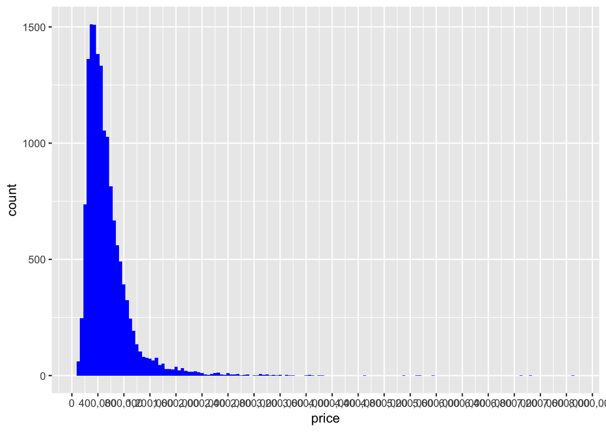

```r
all[!is.na(all$price),] %>%
  ggplot(aes(x=price)) +
  geom_histogram(fill="blue", binwidth=50000) +
  scale_x_continuous(breaks = seq(0, 8000000, by = 400000), labels= comma)
```

#### 3.2 변수별 상관관계 분석

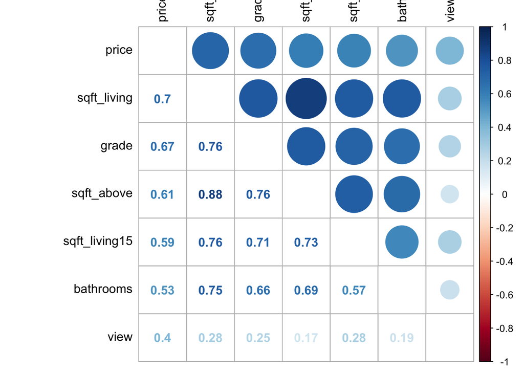

```r
#상관관계 분석
numericVar <- which(sapply(all[!is.na(all$price),], is.numeric))
numericVarNames <- names(numericVar)
all_numVar <- all[, numericVar]
cor_numVar <- cor(all_numVar, use='pairwise.complete.obs')
cor_sorted <- as.matrix(sort(cor_numVar[, 'price'], decreasing = TRUE))
CorHigh <- names(which(apply(cor_sorted, 1, function(x) abs(x) > 0.4)))
cor_numVar <- cor_numVar[CorHigh, CorHigh]
corrplot.mixed(cor_numVar, tl.col='black', tl.pos='lt')
```

- 화장실 수, 전망, 면적, 집 등급이 가격에 영향을 주는 것이 보입니다.
- 그뿐만 아니라 다른 변수들 간의 상관관계도 알 수 있습니다.
- 추후 계속 확인하면서 분석 진행 할 예정입니다.

#### 3.3 date

```r
head(all$date)
```

```
## [1] "20141013T000000" "20150225T000000" "20150218T000000" "20140627T000000"
## [5] "20150115T000000" "20150403T000000"
```

```r
class(all$date)
```

```
## [1] "character"
```

```r
all$date %>% sort(decreasing = T) %>% head
```

```
## [1] "20150527T000000" "20150524T000000" "20150515T000000" "20150514T000000"
## [5] "20150514T000000" "20150514T000000"
```

```r
all$date %>% sort(decreasing = F) %>% head
```

```
## [1] "20140502T000000" "20140502T000000" "20140502T000000" "20140502T000000"
## [5] "20140502T000000" "20140502T000000"
```

```r
all$date <- gsub('T.*','',all$date,ignore.case=TRUE) #문자열 치환, ignore.case=TRUE 옵션은 대소문자 구분

all$date_yyyy <- substr(all$date,1,4)
all$date_mm <- substr(all$date,5,6)
all$date_dd <- substr(all$date,7,8)
all$date_yyyymm <- substr(all$date,1,6)
```

- date 변수 구조 파악 후 중복되는 부분과 다양한 분석을 진행하기 위해 전처리하였습니다.
- date 변수를 년, 월, 일로 구분하였습니다.

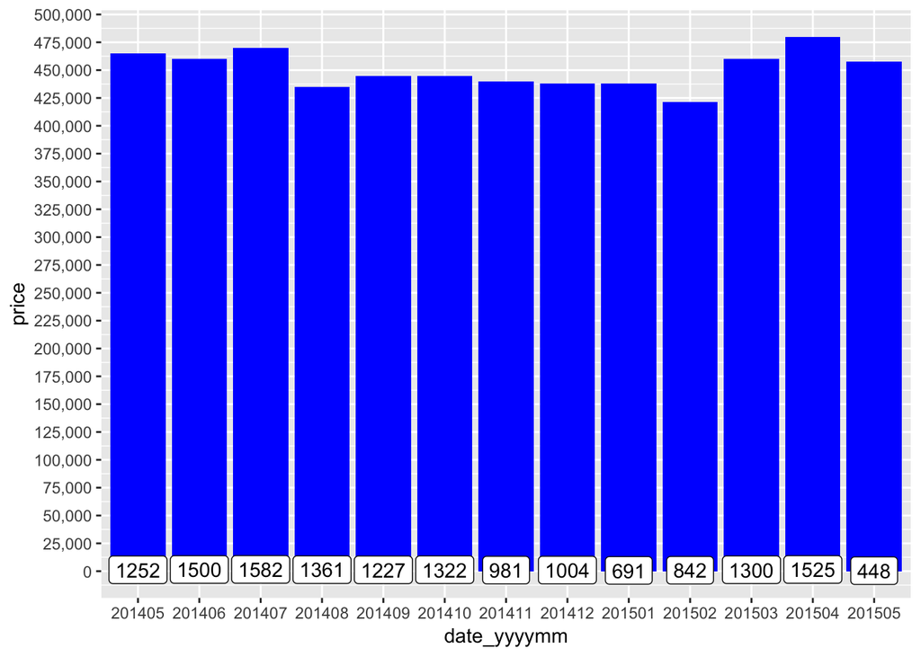

```r
all[!is.na(all$price),] %>%
  ggplot(aes(x=date_yyyymm,price)) +
  geom_bar(stat='summary', fun.y = "median", fill='blue') +
  scale_y_continuous(breaks= seq(0, 5000000, by=25000), labels = comma) +
  geom_label(stat = "count", aes(label = ..count.., y = ..count..))
```

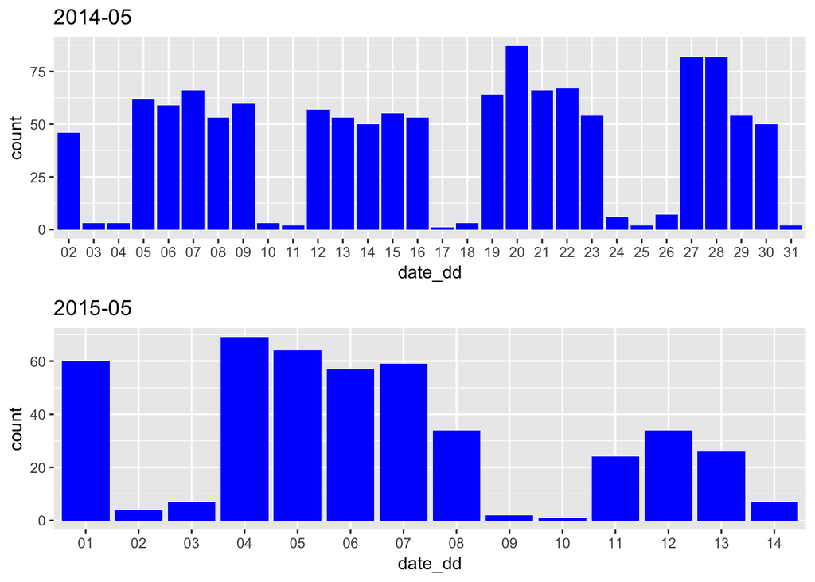

```r
temp_p1 <-
  all[!is.na(all$price),] %>%
  filter(date_yyyymm == 201405) %>%
  ggplot(aes(x=date_dd)) +
  geom_bar(stat='count',fill='blue') +
  ggtitle("2014-05")

temp_p2 <-
  all[!is.na(all$price),] %>%
  filter(date_yyyymm == 201505) %>%
  ggplot(aes(x=date_dd)) +
  geom_bar(stat='count',fill='blue') +
  ggtitle("2015-05")

grid.arrange(temp_p1, temp_p2)
```

- date 변수의 범위는 2014-05 ~ 2015-05로 구성되어 있습니다.
- 중복되는 월은 2014-05와 2015-05가 있고 거래가 된 양이 약 3배 차이가 나는 것을 확인했습니다.
- 2014-05와 2015-05의 차이 나는 이유를 추측해봤을때
- 2015-05-15부터 거래자료가 없고, 거래자료가 없기 전 약 4일 동안은 거래개수가 떨어지는 것을 확인할 수 있습니다.
- 아마도, 거래자료가 없기 전 약 4일 동안은 어차피? 조사가 끝나니까 대충 하지 않았나 싶습니다.

#### 3.4 bathrooms, bedrooms

```r
table(all$bathrooms)
```

```
##
##    0  0.5 0.75    1 1.25  1.5 1.75    2 2.25  2.5 2.75    3 3.25  3.5 3.75
##   10    4   71 3820    9 1438 3029 1921 2034 5364 1183  750  586  729  155
##    4 4.25  4.5 4.75    5 5.25  5.5 5.75    6 6.25  6.5 6.75  7.5 7.75    8
##  135   79   99   23   21   13   10    4    6    2    2    2    1    1    2
```

```r
all %>% select(bathrooms) %>% summary()
```

```
##    bathrooms
##  Min.   :0.000
##  1st Qu.:1.750
##  Median :2.250
##  Mean   :2.116
##  3rd Qu.:2.500
##  Max.   :8.000
```

```r
table(all$bedrooms)
```

```
##
##    0    1    2    3    4    5    6    7    8    9   10   11   33
##   13  195 2746 9764 6860 1592  271   38   13    6    3    1    1
```

```r
all %>% select(bedrooms) %>% summary()
```

```
##     bedrooms
##  Min.   : 0.000
##  1st Qu.: 3.000
##  Median : 3.000
##  Mean   : 3.372
##  3rd Qu.: 4.000
##  Max.   :33.000
```

```r
all %>% filter(bedrooms >= 10)
```

```
## # A tibble: 5 x 24
##   date    price bedrooms bathrooms sqft_living sqft_lot floors waterfront
##   <chr>   <dbl>    <int>     <dbl>       <int>    <int>  <dbl>      <int>
## 1 2014… 1148000       10      5.25        4590    10920      1          0
## 2 2014…  650000       10      2           3610    11914      2          0
## 3 2014…      NA       11      3           3000     4960      2          0
## 4 2014…      NA       33      1.75        1620     6000      1          0
## 5 2014…      NA       10      3           2920     3745      2          0
## # … with 16 more variables: view <int>, condition <int>, grade <int>,
## #   sqft_above <int>, sqft_basement <int>, yr_built <int>,
## #   yr_renovated <int>, zipcode <int>, lat <dbl>, long <dbl>,
## #   sqft_living15 <int>, sqft_lot15 <int>, date_yyyy <chr>, date_mm <chr>,
## #   date_dd <chr>, date_yyyymm <chr>
```

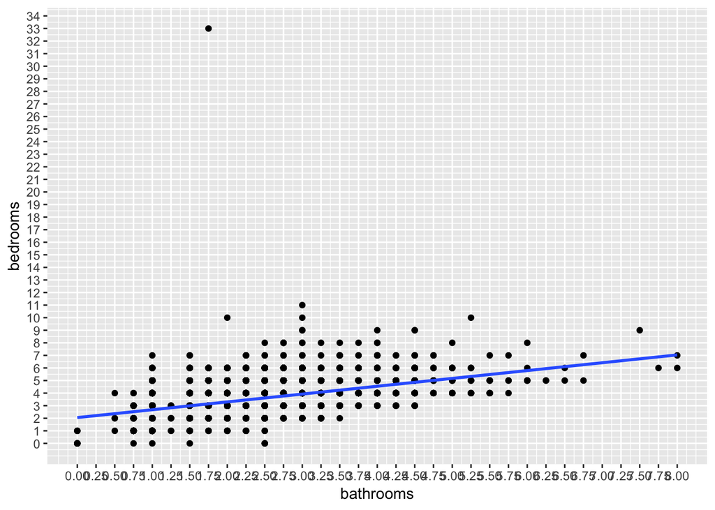

```r
all %>%
  ggplot(aes(x = bathrooms, y = bedrooms)) +
  geom_point() +
  scale_x_continuous(breaks= seq(0, 8, by=.25)) +
  scale_y_continuous(breaks= seq(0, 40, by=1)) +
  stat_smooth(method=lm)
```

```r
cor(all$bathrooms, all$bedrooms)
```

```
## [1] 0.5158569
```

- 화장실 개수에 비해 방 개수가 많은 레코드를 확인할 수 있습니다. (test set에서 나온 레코드로 확인하였습니다.)
- 두 변수의 상관관계 수치는 0.51이므로 연관 있어 보입니다.

#### 3.5 yr_built, yr_renovated

```r
all %>% select(yr_built,yr_renovated) %>% summary()
```

```
##     yr_built     yr_renovated
##  Min.   :1900   Min.   :   0.00
##  1st Qu.:1951   1st Qu.:   0.00
##  Median :1975   Median :   0.00
##  Mean   :1971   Mean   :  84.74
##  3rd Qu.:1997   3rd Qu.:   0.00
##  Max.   :2015   Max.   :2015.00
```

```r
all %>% select(yr_built,yr_renovated) %>% head()
```

```
## # A tibble: 6 x 2
##   yr_built yr_renovated
##      <int>        <int>
## 1     1955            0
## 2     1933            0
## 3     1987            0
## 4     1995            0
## 5     1963            0
## 6     1965            0
```

```r
all %>% select(yr_renovated) %>% table()
```

```
## .
##     0  1934  1940  1944  1945  1946  1948  1950  1951  1953  1954  1955
## 20590     1     2     1     3     2     1     2     1     3     1     3
##  1956  1957  1958  1959  1960  1962  1963  1964  1965  1967  1968  1969
##     3     3     5     1     4     2     4     5     5     2     8     4
##  1970  1971  1972  1973  1974  1975  1976  1977  1978  1979  1980  1981
##     9     2     4     5     3     6     3     8     6    10    10     5
##  1982  1983  1984  1985  1986  1987  1988  1989  1990  1991  1992  1993
##    11    18    18    17    17    18    15    22    25    20    17    19
##  1994  1995  1996  1997  1998  1999  2000  2001  2002  2003  2004  2005
##    19    16    15    15    19    17    35    19    22    36    26    35
##  2006  2007  2008  2009  2010  2011  2012  2013  2014  2015
##    24    35    18    22    18    13    11    37    91    16
```

```r
all %>% select(yr_built,yr_renovated) %>% filter(yr_renovated != 0) #리모델링 한 집 구분
```

```
## # A tibble: 913 x 2
##    yr_built yr_renovated
##       <int>        <int>
##  1     1930         2002
##  2     1900         1999
##  3     1957         1991
##  4     1915         1978
##  5     1904         2005
##  6     1982         2008
##  7     1954         2003
##  8     1905         1994
##  9     1922         1984
## 10     1928         1954
## # … with 903 more rows
```

```r
all$yr_renovated_state <- ifelse(all$yr_renovated == 0, 0, 1) #리모델링 구분 값 추가
table(all$yr_renovated_state)
```

```
##
##     0     1
## 20590   913
```

- 분석에 용이하게 재개발 여부를 구분할 수 있는 구분값(변수)를 추가하였습니다.

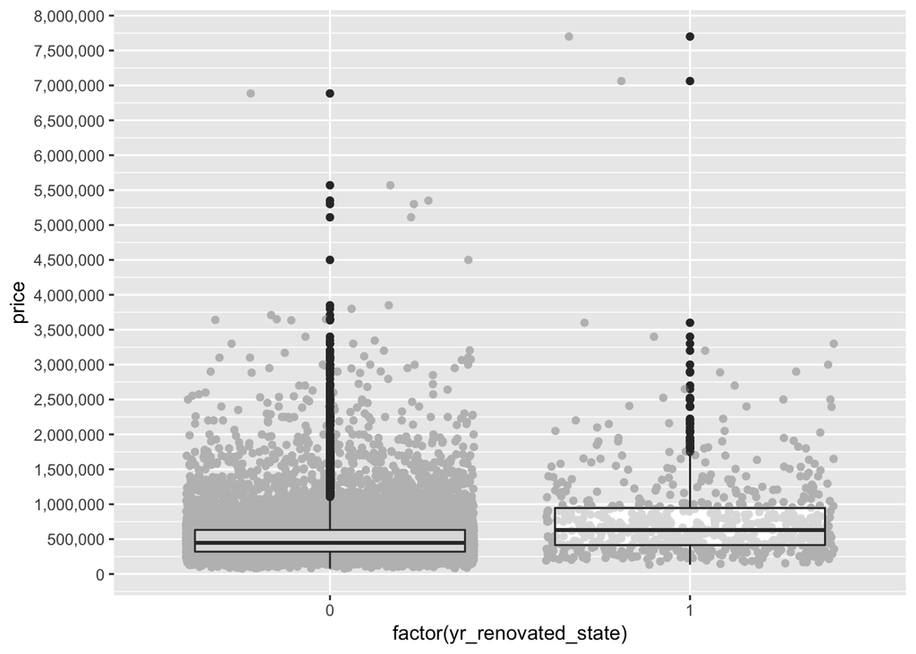

```r
all %>% select(yr_built,yr_renovated,price,yr_renovated_state) %>% filter(!is.na(price)) %>%
  ggplot(aes(x=factor(yr_renovated_state),y=price)) +
  geom_boxplot() +
  geom_jitter(col='gray') +
  geom_boxplot(alpha=.5) +
  scale_y_continuous(breaks= seq(0,8000000, by=500000), labels=comma)
```

- 그래프를 통해 재개발 한 집이 비싼 시세를 갖는 것을 확인할 수 있습니다.

```r
t.test(all$price[all$yr_renovated_state == 0],all$price[all$yr_renovated_state == 1],conf.level=0.95)
```

```
##
##  Welch Two Sample t-test
##
## data:  all$price[all$yr_renovated_state == 0] and all$price[all$yr_renovated_state == 1]
## t = -10.066, df = 646.38, p-value < 2.2e-16
## alternative hypothesis: true difference in means is not equal to 0
## 95 percent confidence interval:
##  -311204.9 -209606.1
## sample estimates:
## mean of x mean of y
##  529753.8  790159.3
```

- 재개발한 집값과 그렇지 않은 집값의 **평균의 차이를 검정해보니 유의한 것을 알 수 있음.**

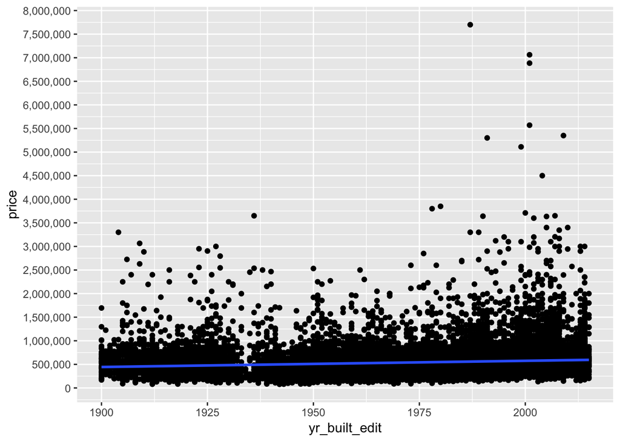

```r
all$yr_built_edit <- ifelse(all$yr_renovated == 0, all$yr_built, all$yr_renovated)

all %>%
  filter(!is.na(price)) %>%
  ggplot(aes(x = yr_built_edit, y = price)) +
  geom_point() +
  scale_y_continuous(breaks= seq(0,8000000, by=500000), labels=comma) +
  stat_smooth(method=lm)
```

- 재건축 여부를 기준으로 yr_built_edit 변수 생성하였습니다.
- 2000년도에 짓거나 재건축한 건물이 조금 더 비싼 것을 알 수 있습니다.

#### 3.6 sqft_living, sqft_living15

```r
all %>% select(sqft_living,sqft_living15) %>% summary()
```

```
##   sqft_living    sqft_living15
##  Min.   :  290   Min.   : 399
##  1st Qu.: 1430   1st Qu.:1490
##  Median : 1914   Median :1840
##  Mean   : 2081   Mean   :1987
##  3rd Qu.: 2550   3rd Qu.:2370
##  Max.   :13540   Max.   :6210
```

```r
all %>% select(sqft_living,sqft_living15) %>% head()
```

```
## # A tibble: 6 x 2
##   sqft_living sqft_living15
##         <int>         <int>
## 1        1180          1340
## 2         770          2720
## 3        1680          1800
## 4        1715          2238
## 5        1060          1650
## 6        3560          2210
```

```r
all %>% select(sqft_living,sqft_living15) %>% filter(sqft_living != sqft_living15) #면적이 바뀐 리스트 확인
```

```
## # A tibble: 18,954 x 2
##    sqft_living sqft_living15
##          <int>         <int>
##  1        1180          1340
##  2         770          2720
##  3        1680          1800
##  4        1715          2238
##  5        1060          1650
##  6        3560          2210
##  7        1160          1330
##  8        1430          1780
##  9        1810          1360
## 10        2950          2140
## # … with 18,944 more rows
```

```r
all$sqft_living_state <- ifelse(all$sqft_living == all$sqft_living15, 0, 1) # 면적 바뀐 집 구분값 추가
all$sqft_living_edit <- ifelse(all$sqft_living == all$sqft_living15, all$sqft_living, all$sqft_living15) #면적 수정 값 추가

table(all$sqft_living_state)
```

```
##
##     0     1
##  2549 18954
```

```r
table(all$yr_renovated_state)
```

```
##
##     0     1
## 20590   913
```

- 분석에 용이하도록 면적이 바뀐 유무 구분 값과 면적이 바뀐 유무를 기준으로 sqft_living_edit 변수 생성하였습니다.
- yr_renovated(재건축연도)의 개수와 sqft_living(면적)이 바뀐 집의 수가 차이가 크게 나는 것을 알 수 있습니다. (분석하면서 고려해봐야 할 것 같습니다.)

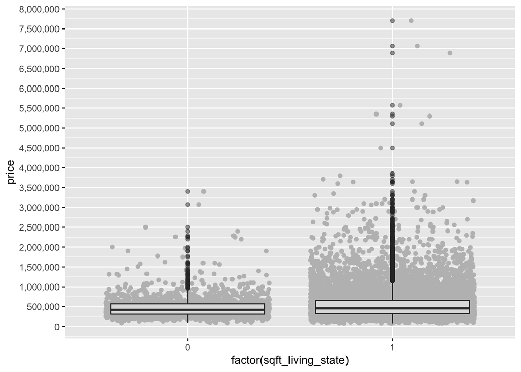

```r
all %>% select(sqft_living_state,price) %>% filter(!is.na(price)) %>%
  ggplot(aes(x=factor(sqft_living_state),y=price)) +
  geom_jitter(col='gray') +
  geom_boxplot(alpha=.5) +
  scale_y_continuous(breaks= seq(0,8000000, by=500000), labels=comma)
```

```r
all %>% select(price,sqft_living_state) %>% filter(!is.na(price) & sqft_living_state == 1) %>% summary()
```

```
##      price         sqft_living_state
##  Min.   :  78000   Min.   :1
##  1st Qu.: 325000   1st Qu.:1
##  Median : 455000   Median :1
##  Mean   : 549188   Mean   :1
##  3rd Qu.: 653000   3rd Qu.:1
##  Max.   :7700000   Max.   :1
```

```r
all %>% select(price,sqft_living_state) %>% filter(!is.na(price) & sqft_living_state == 0) %>% summary()
```

```
##      price         sqft_living_state
##  Min.   :  89000   Min.   :0
##  1st Qu.: 308000   1st Qu.:0
##  Median : 418500   Median :0
##  Mean   : 477222   Mean   :0
##  3rd Qu.: 569995   3rd Qu.:0
##  Max.   :3400000   Max.   :0
```

- 재건축을 진행한 집이 조금 더 높은 사분위 수를 보이고, 그래프를 통해 분산이 큰 것을 알 수 있습니다.

```r
t.test(all$price[all$sqft_living_state == 0],all$price[all$sqft_living_state == 1],conf.level=0.95)
```

```
##
##  Welch Two Sample t-test
##
## data:  all$price[all$sqft_living_state == 0] and all$price[all$sqft_living_state == 1]
## t = -9.8625, df = 2796.1, p-value < 2.2e-16
## alternative hypothesis: true difference in means is not equal to 0
## 95 percent confidence interval:
##  -86274.31 -57658.37
## sample estimates:
## mean of x mean of y
##  477222.1  549188.4
```

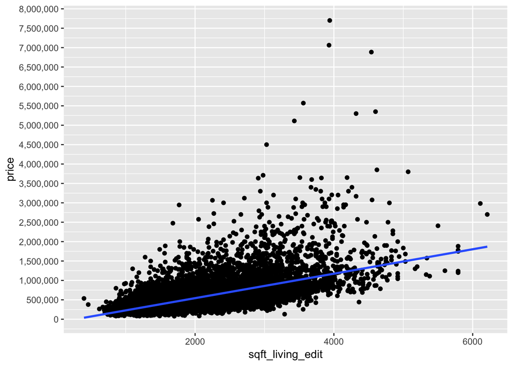

```r
all %>%
  filter(!is.na(price)) %>%
  ggplot(aes(x = sqft_living_edit, y = price)) +
  geom_point() +
  scale_y_continuous(breaks= seq(0,8000000, by=500000), labels=comma) +
  stat_smooth(method=lm)
```

#### 3.7 sqft_lot, sqft_lot15

```r
all %>% select(sqft_lot,sqft_lot15) %>% summary()
```

```
##     sqft_lot         sqft_lot15
##  Min.   :    520   Min.   :   651
##  1st Qu.:   5040   1st Qu.:  5100
##  Median :   7616   Median :  7620
##  Mean   :  15117   Mean   : 12774
##  3rd Qu.:  10686   3rd Qu.: 10085
##  Max.   :1651359   Max.   :871200
```

```r
all %>% select(sqft_lot,sqft_lot15) %>% head()
```

```
## # A tibble: 6 x 2
##   sqft_lot sqft_lot15
##      <int>      <int>
## 1     5650       5650
## 2    10000       8062
## 3     8080       7503
## 4     6819       6819
## 5     9711       9711
## 6     9796       8925
```

```r
all %>% select(sqft_lot,sqft_lot15) %>% filter(sqft_lot != sqft_lot15) #부지 면적이 바뀐 리스트 확인
```

```
## # A tibble: 17,047 x 2
##    sqft_lot sqft_lot15
##       <int>      <int>
##  1    10000       8062
##  2     8080       7503
##  3     9796       8925
##  4    19901      12697
##  5     9680      10208
##  6     5000       4000
##  7    14040      14018
##  8     9850       5095
##  9     9774       8850
## 10    44867      20336
## # … with 17,037 more rows
```

```r
all$sqft_lot_state <- ifelse(all$sqft_lot == all$sqft_lot15, 0, 1) # 부지 면적 바뀐 집 구분값 추가
all$sqft_lot_edit <- ifelse(all$sqft_lot == all$sqft_lot15, all$sqft_lot, all$sqft_lot15) #부지 면적 수정 값 추가
table(all$sqft_lot_state)
```

```
##
##     0     1
##  4456 17047
```

- 분석에 용이하도록 부지 면적 변경된 집 구분 값을 추가하였습니다.
- 부지 면적이 바뀐 집 기준으로 부지 면적 값(변수) sqft_lot_edit 생성하였습니다.

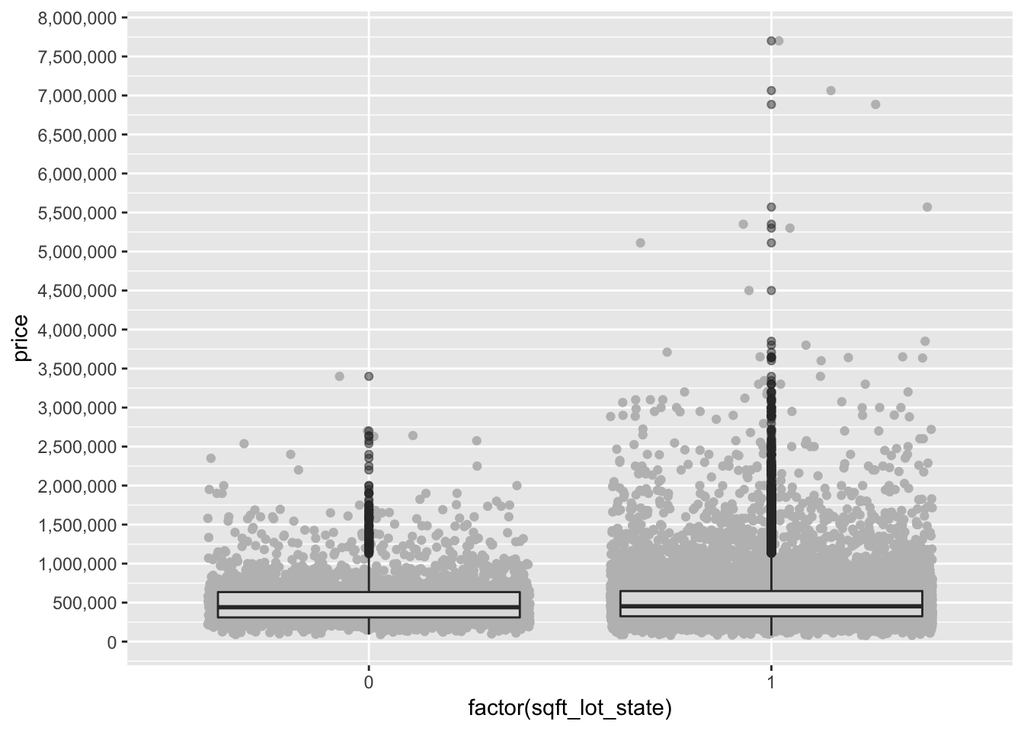

```r
all %>% select(sqft_lot_state,price) %>% filter(!is.na(price)) %>%
  ggplot(aes(x=factor(sqft_lot_state),y=price)) +
  geom_jitter(col='gray') +
  geom_boxplot(alpha=.5) +
  scale_y_continuous(breaks= seq(0,8000000, by=500000), labels=comma)
```

```r
all %>% select(price,sqft_lot_state) %>% filter(!is.na(price) & sqft_lot_state == 1) %>% summary()
```

```
##      price         sqft_lot_state
##  Min.   :  78000   Min.   :1
##  1st Qu.: 325000   1st Qu.:1
##  Median : 452500   Median :1
##  Mean   : 547460   Mean   :1
##  3rd Qu.: 648090   3rd Qu.:1
##  Max.   :7700000   Max.   :1
```

```r
all %>% select(price,sqft_lot_state) %>% filter(!is.na(price) & sqft_lot_state == 0) %>% summary()
```

```
##      price         sqft_lot_state
##  Min.   :  90000   Min.   :0
##  1st Qu.: 310000   1st Qu.:0
##  Median : 440500   Median :0
##  Mean   : 514747   Mean   :0
##  3rd Qu.: 635000   3rd Qu.:0
##  Max.   :3400000   Max.   :0
```

- summary로 보았을 때는 별 차이가 없어 보입니다.
- 그래프로 보았을 때는 부지 면적이 바뀐 집은 가격 분산이 크다는 것을 알 수 있습니다.

```r
t.test(all$price[all$sqft_lot_state == 0],all$price[all$sqft_lot_state == 1],conf.level=0.95)
```

```
##
##  Welch Two Sample t-test
##
## data:  all$price[all$sqft_lot_state == 0] and all$price[all$sqft_lot_state == 1]
## t = -5.0575, df = 6077.8, p-value = 4.372e-07
## alternative hypothesis: true difference in means is not equal to 0
## 95 percent confidence interval:
##  -45393.46 -20033.32
## sample estimates:
## mean of x mean of y
##  514746.9  547460.3
```

- 부지 면적이 바뀐 집과 바뀌지 않은 집의 **평균의 차이는 유의미 해입니다.**

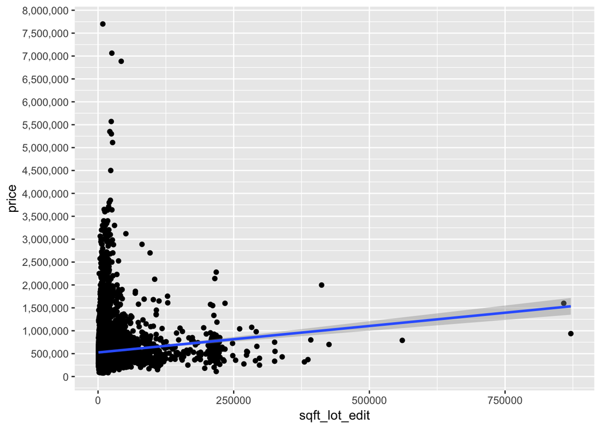

```r
all %>%
  filter(!is.na(price)) %>%
  ggplot(aes(x = sqft_lot_edit, y = price)) +
  geom_point() +
  scale_y_continuous(breaks= seq(0,8000000, by=500000), labels=comma) +
  stat_smooth(method=lm)
```

```r
cor(all$sqft_lot_edit, all$price, use='pairwise.complete.obs')
```

```
## [1] 0.08638433
```

#### 3.8 면적을 나타내는 변수들(sqft_above, sqft_basement, sqft_living, sqft_lot)

```r
all %>%
  select(sqft_living,sqft_living_edit,sqft_lot, sqft_lot_edit, sqft_above, sqft_basement) %>%
  mutate(
    above_basement_sum = sqft_above+sqft_basement
  ) %>%
  summary()
```

```
##   sqft_living    sqft_living_edit    sqft_lot       sqft_lot_edit
##  Min.   :  290   Min.   : 399     Min.   :    520   Min.   :   651
##  1st Qu.: 1430   1st Qu.:1490     1st Qu.:   5040   1st Qu.:  5100
##  Median : 1914   Median :1840     Median :   7616   Median :  7620
##  Mean   : 2081   Mean   :1987     Mean   :  15117   Mean   : 12774
##  3rd Qu.: 2550   3rd Qu.:2370     3rd Qu.:  10686   3rd Qu.: 10085
##  Max.   :13540   Max.   :6210     Max.   :1651359   Max.   :871200
##    sqft_above   sqft_basement    above_basement_sum
##  Min.   : 290   Min.   :   0.0   Min.   :  290
##  1st Qu.:1200   1st Qu.:   0.0   1st Qu.: 1430
##  Median :1560   Median :   0.0   Median : 1914
##  Mean   :1790   Mean   : 291.7   Mean   : 2081
##  3rd Qu.:2210   3rd Qu.: 560.0   3rd Qu.: 2550
##  Max.   :9410   Max.   :4820.0   Max.   :13540
```

```r
cor(all$sqft_living, (all$sqft_above+all$sqft_basement)) # 두 변수가 동일한지 확인
```

```
## [1] 1
```

- 상관계수를 통해 *2015년 이전* 주거 공간 면적 = 지하실을 제외한 면적 + 지하실 면적임을 알 수 있습니다.

#### 3.9 floors

```r
all %>% select(floors) %>% summary()
```

```
##      floors
##  Min.   :1.000
##  1st Qu.:1.000
##  Median :1.500
##  Mean   :1.495
##  3rd Qu.:2.000
##  Max.   :3.500
```

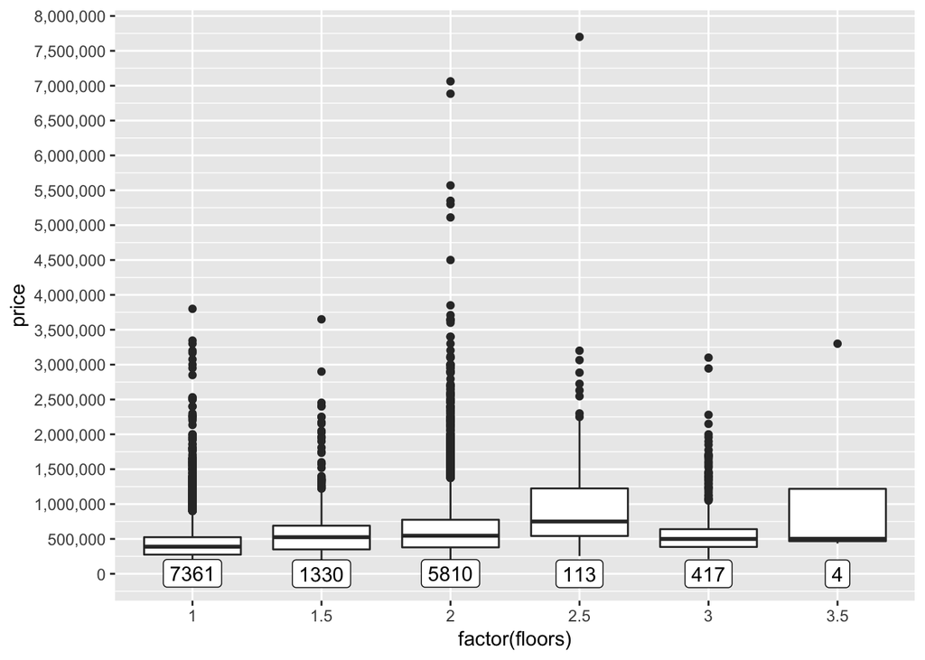

```r
all %>% select(price,floors) %>% filter(!is.na(price)) %>%
  ggplot(aes(x=factor(floors),y=price)) +
  geom_boxplot() +
  geom_label(stat='count', aes(label= ..count.., y= ..count..)) +
  scale_y_continuous(breaks= seq(0,8000000, by=500000), labels=comma)
```

- 1층, 2층 집의 개수가 많습니다.
- 다락방이 있는 집은 전반적으로 가격이 올라가는 것을 알 수 있습니다.
- 3층은 2.5층(다락방포함)에 비해 전반적인 가격은 내려가지만 3Q 이상인 가격이 많이 있는 것을 알 수 있습니다.

#### 3.10 waterfront

```r
all %>% select(waterfront) %>% table()
```

```
## .
##     0     1
## 21340   163
```

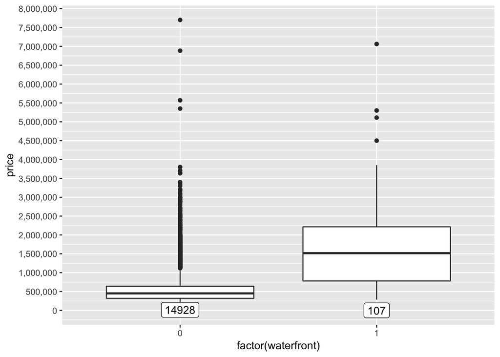

```r
all %>% select(price,waterfront) %>% filter(!is.na(price)) %>%
  ggplot(aes(x=factor(waterfront),y=price)) +
  geom_boxplot() +
  geom_label(stat='count', aes(label= ..count.., y= ..count..)) +
  scale_y_continuous(breaks= seq(0,8000000, by=500000), labels=comma)
```

```r
all %>% select(price,waterfront) %>% filter(waterfront==0) %>% summary()
```

```
##      price           waterfront
##  Min.   :  78000   Min.   :0
##  1st Qu.: 320000   1st Qu.:0
##  Median : 450000   Median :0
##  Mean   : 532324   Mean   :0
##  3rd Qu.: 640000   3rd Qu.:0
##  Max.   :7700000   Max.   :0
##  NA's   :6412
```

- 리버뷰 집값이 더 비싼 것을 확인할 수 있습니다.
- 리버뷰가 아닌 집이 대부분인 것을 알 수 있습니다.

#### 3.11 view(집 외관)

```r
all %>% select(view) %>% table()
```

```
## .
##     0     1     2     3     4
## 19385   332   962   507   317
```

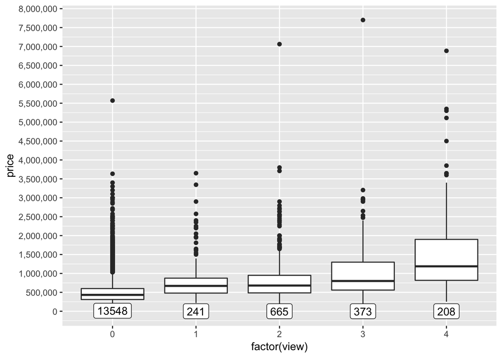

```r
all %>% select(price,view) %>% filter(!is.na(price)) %>%
  ggplot(aes(x=factor(view),y=price)) +
  geom_boxplot() +
  geom_label(stat='count', aes(label= ..count.., y= ..count..)) +
  scale_y_continuous(breaks= seq(0,8000000, by=500000), labels=comma)
```

```r
view_summary <- list()
for(i in 0:4){
  view_summary[[i+1]] <- all %>% filter(view==i & !is.na(price)) %>% select(price) %>% summary()
  #test <- rbind(tset, test)
}
print(view_summary)
```

```
## [[1]]
##      price
##  Min.   :  78000
##  1st Qu.: 311000
##  Median : 433000
##  Mean   : 496286
##  3rd Qu.: 600000
##  Max.   :5570000
##
## [[2]]
##      price
##  Min.   : 217000
##  1st Qu.: 480000
##  Median : 670000
##  Mean   : 787206
##  3rd Qu.: 875000
##  Max.   :3650000
##
## [[3]]
##      price
##  Min.   : 169317
##  1st Qu.: 485000
##  Median : 680000
##  Mean   : 805655
##  3rd Qu.: 950000
##  Max.   :7062500
##
## [[4]]
##      price
##  Min.   : 154000
##  1st Qu.: 560000
##  Median : 800000
##  Mean   : 986628
##  3rd Qu.:1298000
##  Max.   :7700000
##
## [[5]]
##      price
##  Min.   : 252000
##  1st Qu.: 817500
##  Median :1187500
##  Mean   :1499979
##  3rd Qu.:1899250
##  Max.   :6885000
```

- 등급 1~4는 등급 0보다 크다는 것을 확연히 알 수 있습니다.

#### 3.12 condition

```r
all %>% select(condition) %>% table()
```

```
## .
##     1     2     3     4     5
##    29   167 13961  5657  1689
```

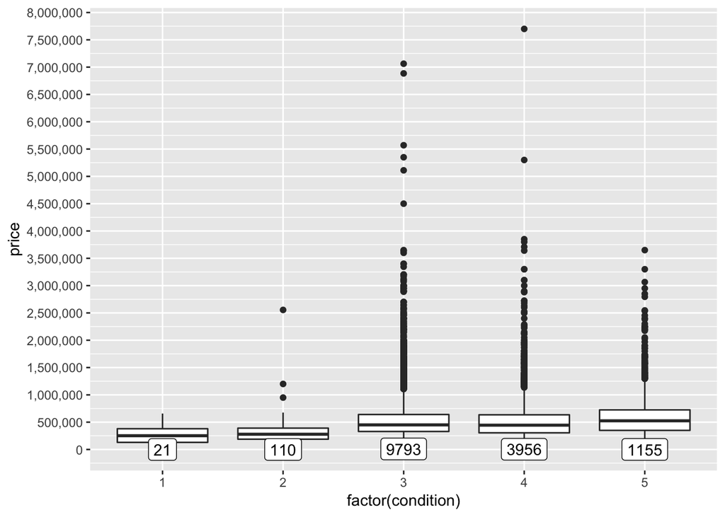

```r
all %>% select(price,condition) %>% filter(!is.na(price)) %>%
  ggplot(aes(x=factor(condition),y=price)) +
  geom_boxplot() +
  geom_label(stat='count', aes(label= ..count.., y= ..count..)) +
  scale_y_continuous(breaks= seq(0,8000000, by=500000), labels=comma)
```

```r
condition_summary <- list()
for(i in 1:5){
  condition_summary[[i]] <- all %>% filter(condition==i & !is.na(price)) %>% select(price) %>% summary()
}
print(condition_summary)
```

```
## [[1]]
##      price
##  Min.   : 78000
##  1st Qu.:130000
##  Median :252000
##  Mean   :276593
##  3rd Qu.:380000
##  Max.   :658000
##
## [[2]]
##      price
##  Min.   :  80000
##  1st Qu.: 188250
##  Median : 279000
##  Mean   : 325229
##  3rd Qu.: 391050
##  Max.   :2555000
##
## [[3]]
##      price
##  Min.   :  83000
##  1st Qu.: 329950
##  Median : 450000
##  Mean   : 541063
##  3rd Qu.: 640000
##  Max.   :7062500
##
## [[4]]
##      price
##  Min.   :  89000
##  1st Qu.: 305000
##  Median : 445000
##  Mean   : 526107
##  3rd Qu.: 635000
##  Max.   :7700000
##
## [[5]]
##      price
##  Min.   : 110000
##  1st Qu.: 350000
##  Median : 525000
##  Mean   : 612704
##  3rd Qu.: 725000
##  Max.   :3650000
```

- 1,2 등급의 비중이 적은걸 알 수 있습니다.

#### 3.13 zipcode

```r
zipcode_group <-
all %>%
  group_by(zipcode) %>%
  summarize(
    mean_price = mean(price,na.rm = TRUE),
    median_price = median(price,na.rm = TRUE),
    cnt = n()
  ) %>%
  arrange(median_price) %>%
  mutate(
    cum_cnt = cumsum(cnt), #누적합
    zipcode_group = factor(ntile(cum_cnt, 10)) #n 개의 동일한 개수로 데이터셋 나눔
  ) %>%
  select(zipcode,zipcode_group)

all <- left_join(all,zipcode_group, by=c("zipcode"))
```

- 우리나라와 동일하게 지역마다 주택 가격이 상의할 것으로 예상하고, zipcode별 중앙값으로 정렬 후 10개의 등급으로 구분하였습니다.

#### 3.14 grade

```r
all %>% select(grade) %>% table()
```

```
## .
##    1    3    4    5    6    7    8    9   10   11   12   13
##    1    3   29  236 2017 8929 6050 2609 1131  396   89   13
```

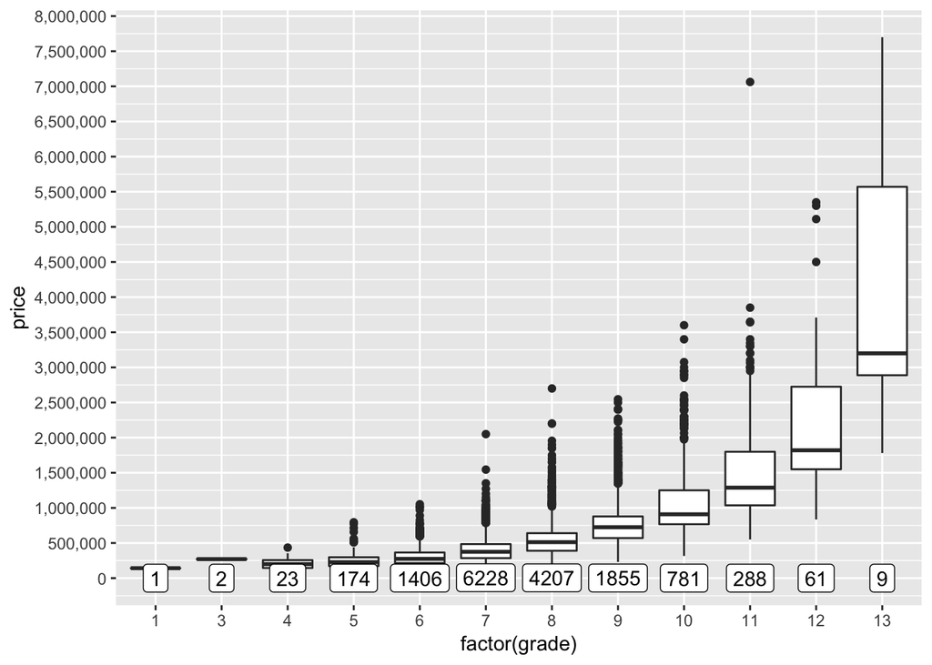

```r
all %>% select(price,grade) %>% filter(!is.na(price)) %>%
  ggplot(aes(x=factor(grade),y=price)) +
  geom_boxplot() +
  geom_label(stat='count', aes(label= ..count.., y= ..count..)) +
  scale_y_continuous(breaks= seq(0,8000000, by=500000), labels=comma)
```

- 등급이 높을수록 집 가격이 올라가는 것이 두드러져 보입니다. (변수 중 가장 가격을 잘 나타내는 것 같습니다.)

##### 3.1.1 이상치 확인

```r
all %>%
  mutate(
    UpperQ = fivenum(price)[4],
    LowerQ = fivenum(price)[2],
    IQR = UpperQ - LowerQ
  ) %>%
  filter(
    price > (UpperQ+IQR*1.5) & grade == 7 & !is.na(price)
  ) %>% arrange(desc(price))
```

```
## # A tibble: 6 x 34
##   date   price bedrooms bathrooms sqft_living sqft_lot floors waterfront
##   <chr>  <dbl>    <int>     <dbl>       <int>    <int>  <dbl>      <int>
## 1 2015… 2.05e6        4      3.25        3580    19989    1.5          1
## 2 2015… 1.54e6        4      2.25        2640     3000    2            0
## 3 2014… 1.35e6        3      2           2070     9600    1            0
## 4 2014… 1.27e6        5      2.5         3200    17204    1            0
## 5 2014… 1.20e6        3      2           2480    13310    1            0
## 6 2014… 1.15e6        3      2           2110    18815    2            0
## # … with 26 more variables: view <int>, condition <int>, grade <int>,
## #   sqft_above <int>, sqft_basement <int>, yr_built <int>,
## #   yr_renovated <int>, zipcode <int>, lat <dbl>, long <dbl>,
## #   sqft_living15 <int>, sqft_lot15 <int>, date_yyyy <chr>, date_mm <chr>,
## #   date_dd <chr>, date_yyyymm <chr>, yr_renovated_state <dbl>,
## #   yr_built_edit <int>, sqft_living_state <dbl>, sqft_living_edit <int>,
## #   sqft_lot_state <dbl>, sqft_lot_edit <int>, zipcode_group <fct>,
## #   UpperQ <dbl>, LowerQ <dbl>, IQR <dbl>
```

```r
all %>%
  filter(
    price >= 2050000 & sqft_living <= 4000 & sqft_living >= 3500
  ) %>% arrange(price)
```

```
## # A tibble: 20 x 31
##    date   price bedrooms bathrooms sqft_living sqft_lot floors waterfront
##    <chr>  <dbl>    <int>     <dbl>       <int>    <int>  <dbl>      <int>
##  1 2015… 2.05e6        5      3           3830     8480    2            0
##  2 2015… 2.05e6        4      3.25        3580    19989    1.5          1
##  3 2014… 2.10e6        4      1.75        3550    19865    2            0
##  4 2014… 2.13e6        4      3.25        3860    17820    1            0
##  5 2015… 2.15e6        4      3.25        3840     6214    1.5          0
##  6 2014… 2.20e6        4      3           3540    11098    2            0
##  7 2014… 2.20e6        3      2           3570    30456    1            0
##  8 2014… 2.20e6        4      3.75        3790     7200    2            0
##  9 2014… 2.23e6        3      3           3620    28064    2            1
## 10 2014… 2.23e6        3      3.5         3760     5634    2            1
## 11 2014… 2.25e6        3      3.25        3890     3452    2            0
## 12 2014… 2.38e6        5      2.5         3650     9050    2            0
## 13 2014… 2.40e6        4      3.25        3800    19798    2            0
## 14 2014… 2.40e6        4      2.5         3650     8354    1            1
## 15 2015… 2.50e6        4      3.25        3960    16224    2            0
## 16 2015… 2.54e6        4      3           3710    20000    2            0
## 17 2014… 2.72e6        4      3.25        3990    18115    2            0
## 18 2015… 2.90e6        5      2.5         3750    91681    2            1
## 19 2014… 2.95e6        4      3.25        3890    25470    2            1
## 20 2014… 3.10e6        3      3           3920    13085    2            1
## # … with 23 more variables: view <int>, condition <int>, grade <int>,
## #   sqft_above <int>, sqft_basement <int>, yr_built <int>,
## #   yr_renovated <int>, zipcode <int>, lat <dbl>, long <dbl>,
## #   sqft_living15 <int>, sqft_lot15 <int>, date_yyyy <chr>, date_mm <chr>,
## #   date_dd <chr>, date_yyyymm <chr>, yr_renovated_state <dbl>,
## #   yr_built_edit <int>, sqft_living_state <dbl>, sqft_living_edit <int>,
## #   sqft_lot_state <dbl>, sqft_lot_edit <int>, zipcode_group <fct>
```

- 집 등급(grade)이 7등급인 이상치를 집들을 확인해본 결과, 최고 금액(2,050,000)을 가진 집과 비슷한 면적을 가진 집을 비교해보니 변수 대부분은 비슷하고 높은 view를 가지고 있는 것을 알 수 있습니다.
- 높은 view로 인해 등급 대비 높은 가격에 거래되고 있을 수도 있다고 판단됩니다.

```r
all %>%
  mutate(
    UpperQ = fivenum(price)[4],
    LowerQ = fivenum(price)[2],
    IQR = UpperQ - LowerQ
  ) %>%
  filter(
    price > (UpperQ+IQR*1.5) & grade == 8 & !is.na(price)
  ) %>%
  arrange(desc(price)) %>%
  select(date,price,bedrooms,bathrooms,sqft_living,sqft_lot,view,zipcode_group)
```

```
## # A tibble: 83 x 8
##    date   price bedrooms bathrooms sqft_living sqft_lot  view zipcode_group
##    <chr>  <dbl>    <int>     <dbl>       <int>    <int> <int> <fct>
##  1 2014… 2.70e6        5      4           4230    27295     4 9
##  2 2015… 2.20e6        5      4.25        4640    22703     4 8
##  3 2014… 2.20e6        3      2           3570    30456     1 10
##  4 2015… 1.96e6        3      1.75        3330    12566     4 10
##  5 2014… 1.90e6        6      4           3020    13237     4 6
##  6 2015… 1.85e6        4      2.5         4120    14866     4 10
##  7 2014… 1.85e6        4      3.25        3480     6000     0 9
##  8 2014… 1.75e6        4      2.5         3910    22710     0 10
##  9 2014… 1.70e6        5      2           2500    15250     4 7
## 10 2015… 1.66e6        4      2.25        3530     5500     0 9
## # … with 73 more rows
```

```r
all %>%
  mutate(
    UpperQ = fivenum(price)[4],
    LowerQ = fivenum(price)[2],
    IQR = UpperQ - LowerQ
  ) %>%
  filter(
    price > (UpperQ+IQR*1.5) & grade == 11 & !is.na(price)
  ) %>%
  arrange(desc(price)) %>%
  select(date,price,bedrooms,bathrooms,sqft_living,sqft_lot,view,zipcode_group)
```

```
## # A tibble: 188 x 8
##    date   price bedrooms bathrooms sqft_living sqft_lot  view zipcode_group
##    <chr>  <dbl>    <int>     <dbl>       <int>    <int> <int> <fct>
##  1 2014… 7.06e6        5      4.5        10040    37325     2 10
##  2 2014… 3.85e6        4      4.25        5770    21300     4 10
##  3 2015… 3.65e6        6      4.75        5480    19401     4 9
##  4 2014… 3.64e6        4      3.25        4830    22257     4 10
##  5 2015… 3.40e6        4      4           4260    11765     0 10
##  6 2015… 3.34e6        5      3.75        5350    15360     1 10
##  7 2014… 3.30e6        5      4.75        6200    13873     4 7
##  8 2014… 3.30e6        3      3.25        4220    41300     4 7
##  9 2014… 3.20e6        4      4           4810    18851     3 10
## 10 2015… 3.20e6        3      3.25        4560    13363     4 10
## # … with 178 more rows
```

- 집 등급(grade)이 11등급 중 가장 비싼 집은 평수(sqft_living)가 굉장히 큰 것을 알 수 있습니다.

```r
all %>%
  mutate(
    UpperQ = fivenum(price)[4],
    LowerQ = fivenum(price)[2],
    IQR = UpperQ - LowerQ
  ) %>%
  filter(
    price > (UpperQ+IQR*1.5) & grade == 12 & !is.na(price)
  ) %>%
  arrange(desc(price)) %>%
  select(date,price,bedrooms,bathrooms,sqft_living,sqft_lot,view,zipcode_group)
```

```
## # A tibble: 57 x 8
##    date   price bedrooms bathrooms sqft_living sqft_lot  view zipcode_group
##    <chr>  <dbl>    <int>     <dbl>       <int>    <int> <int> <fct>
##  1 2015… 5.35e6        5      5           8000    23985     4 10
##  2 2015… 5.30e6        6      6           7390    24829     4 10
##  3 2014… 5.11e6        5      5.25        8010    45517     4 9
##  4 2014… 4.50e6        5      5.5         6640    40014     4 4
##  5 2014… 3.71e6        4      3.5         5550    28078     2 10
##  6 2015… 3.65e6        5      3.75        5020     8694     1 10
##  7 2014… 3.64e6        5      6           5490    19897     0 10
##  8 2014… 3.30e6        8      4           7710    11750     0 10
##  9 2014… 3.17e6        5      3.5         4330    11979     4 10
## 10 2014… 3.12e6        3      3.5         4490    56609     4 5
## # … with 47 more rows
```

- 집 등급(grade)이 12등급에서는 별다른 특잇값이 보이지 않습니다.

### 4. 모델링을 위한 데이터 준비

#### 4.1 랜덤 포레스트를 통해 중요 변수 확인

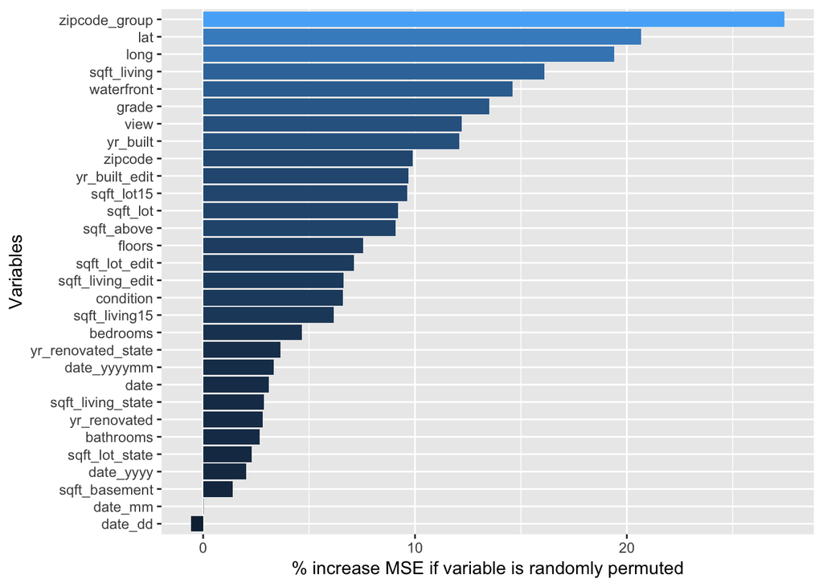

```r
set.seed(2018)
quick_RF <- randomForest(x=all[!is.na(all$price),-2], y=all[!is.na(all$price),]$price, ntree=100,importance=TRUE)
imp_RF <- importance(quick_RF)
imp_DF <- data.frame(Variables = row.names(imp_RF), MSE = imp_RF[,1])
imp_DF <- imp_DF[order(imp_DF$MSE, decreasing = TRUE),]

ggplot(imp_DF, aes(x=reorder(Variables, MSE), y=MSE, fill=MSE)) +
  geom_bar(stat = 'identity') +
  labs(x = 'Variables', y= '% increase MSE if variable is randomly permuted') +
  coord_flip() +
  theme(legend.position="none")
```

- 집값에 영향을 미치는 변수룰 확인할 수 있습니다.

#### 4.2 Lasso 모델 데이터 준비

```r
lasso_fitting_data <- all[!is.na(all$price),c('lat','long', 'yr_built', 'sqft_living', 'zipcode', 'grade', 'sqft_living15', 'sqft_lot15', 'view', 'sqft_lot', 'waterfront' ,'sqft_above', 'floors', 'condition', 'bedrooms', 'sqft_basement', 'bathrooms', 'date_yyyymm','zipcode_group')]

lasso_fitting_data <- model.matrix(~.-1, data=lasso_fitting_data)
```

- 설명변수를 최소화하기위해 겹치거나, 중요도가 떨어지는 변수는 제외합니다.

#### 4.2 XGBoosting 모델 데이터 준비

```r
XGB_fitting_data <- all[!is.na(all$price),c('lat','long' ,'yr_built' ,'sqft_living', 'zipcode' ,'grade' ,'sqft_living15' ,'sqft_lot15' ,'view' ,'sqft_lot' ,'waterfront' ,'sqft_above' ,'floors' ,'condition' ,'bedrooms', 'sqft_basement', 'bathrooms', 'date_yyyymm','zipcode_group')]

XGB_fitting_data$date_yyyymm <- as.numeric(XGB_fitting_data$date_yyyymm)
XGB_fitting_data$zipcode_group <- as.numeric(XGB_fitting_data$zipcode_group)
```

### 5. 모델링

#### 5.1 Lasso

```r
la_control <- trainControl(method="cv", number=5)
tune_grid <- expand.grid(alpha = 1, lambda = c(0.00001, 0.0001, 0.001, 0.01, 0.1)) #alpha=0 ridge, alpha=1 lasso

fit_lasso <- train(
  x = lasso_fitting_data,
  y = all$price[!is.na(all$price)],
  method="glmnet",
  trControl = la_control,
  tuneGrid = tune_grid
)

fit_lasso$bestTune
```

```
##   alpha lambda
## 5     1    0.1
```

```r
RMSE(predict(fit_lasso, lasso_fitting_data), all$price[!is.na(all$price)])
```

```
## [1] 181219.3
```

- 훈련셋으로 RMSE 확인합니다.

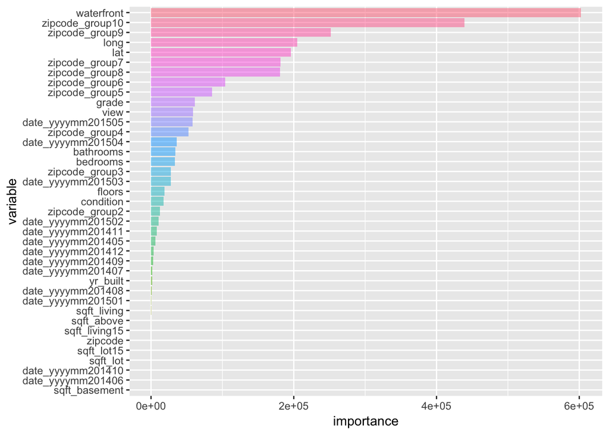

```r
fit_lasso_variable_info <- caretVariableImportanceImgView(fit_lasso)
fit_lasso_variable_info$graph
```

```r
fit_lasso_variable_info$catCount
```

```
## [1] "uses 36 variables in its model, and did not select 3 variables."
```

- 변수 중요도 확인합니다.

#### 5.2 XGBoosting

```r
xgb_grid = expand.grid(
  nrounds = 1000,
  eta = c(0.1, 0.05),
  max_depth = c(2, 3, 4),
  gamma = 0,
  colsample_bytree=1,
  min_child_weight=c(1, 2, 3, 4),
  subsample=1
)

my_control <- trainControl(method="cv", number = 5, verboseIter = T, returnData = F)
#fit_xgb <- train(x=XGB_fitting_data, y=all$price[!is.na(all$price)], method='xgbTree', trControl= my_control, tuneGrid=xgb_grid)
#fit_xgb$bestTune

# max_depth = 4
# eta = 0.1
# min_child_weight = 2

dtrain <- xgb.DMatrix(data = as.matrix(XGB_fitting_data), label=all$price[!is.na(all$price)])

default_param<-list(
  objective = "reg:linear",
  booster = "gbtree",
  eta=0.1, #default = 0.3
  gamma=0,
  max_depth=4, #default=6
  min_child_weight=2, #default=1
  subsample=1,
  colsample_bytree=1
)

xgbcv <- xgb.cv( params = default_param, data = dtrain, nrounds = 500, nfold = 5, showsd = T, stratified = T, print_every_n = 40, early_stopping_rounds = 10, maximize = F)
```

[output not shown]

```r
xgb_mod <- xgb.train(data = dtrain, params=default_param, nrounds = 276)
```

```r
RMSE(predict(xgb_mod, dtrain), all$price[!is.na(all$price)])
```

```
## [1] 80013.69
```

- 훈련셋으로 RMSE 확인합니다.

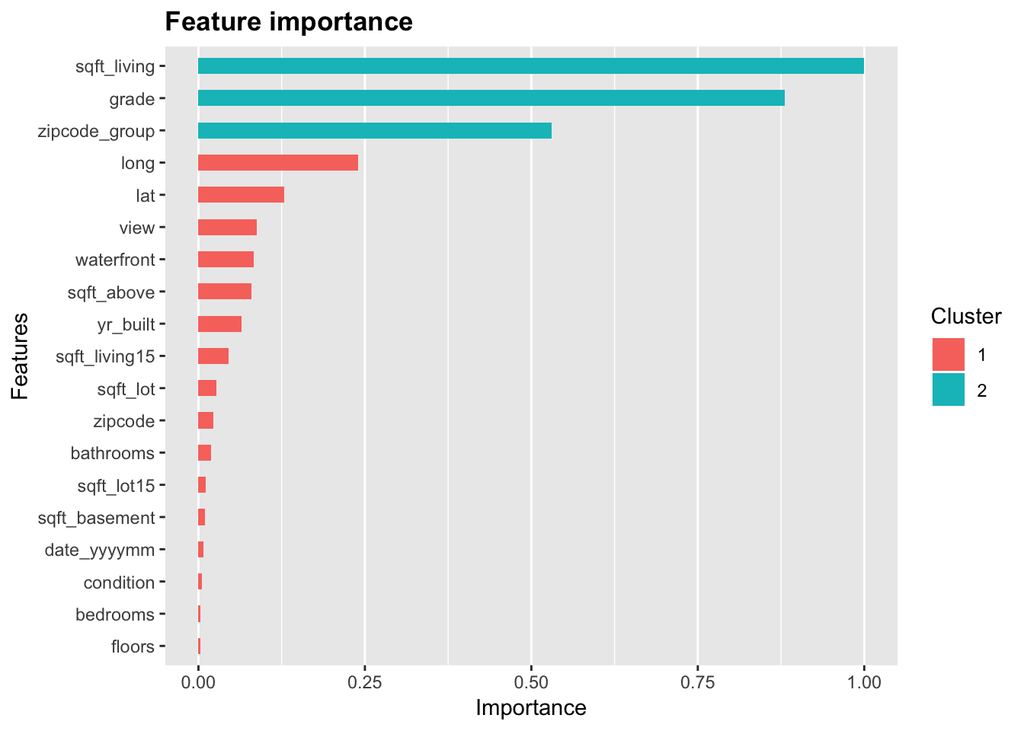

```r
mat <- xgb.importance (feature_names = colnames(dtrain),model = xgb_mod)
xgb.ggplot.importance(importance_matrix = mat, rel_to_first = TRUE)
```

- 변수 중요도 확인합니다.